# 데이터 마이닝 실습 자료

경상국립대 정보통계학과 김성돈

2022 02 23

## 작업 디렉토리 설정

```r
### 현재 사용하는 디렉토리 확인
getwd()
```

```
## [1] "C:/Users/a3011/OneDrive/Desktop"
```

```r
### 작업 디렉토리 변경
setwd('C:\\Users\\a3011\\OneDrive\\Desktop')
```

```r
### 디렉토리 확인
getwd()
```

```
## [1] "C:/Users/a3011/OneDrive/Desktop"
```

```r
### 디렉토리 내 어떤 파일이 있는지 확인
dir()
```

```
##  [1] "~$kikihoho.pptx"
##  [2] "2021년+창립50주년+기념+추계학술논문발표회+일정표V8(김성돈).pdf"
##  [3] "Agarch simulation(complete)"
##  [4] "asdsad.txt"
##  [5] "bert_pre_training of deep bidirectional transformers for language understanding.pdf"
##  [6] "bodyPerformance.csv"
##  [7] "Desktop.egg"
##  [8] "desktop.ini"
##  [9] "ggpairs_image.png"
## [10] "ghfhjghjghjk.html"
## [11] "ghfhjghjghjk.Rmd"
## [12] "GitHub Desktop.lnk"
## [13] "LH 공모전 준비자료"
## [14] "mri 논문"
## [15] "R을 이용한 빅데이터 분석 기초교육(2022_02_16).egg"
```

[output cut: 17 more lines]

## 사용할 데이터 불러오기

```r
body_df <- read.csv("bodyPerformance.csv")
```

```r
### 데이터프레임 head 보기
head(body_df)
```

```
##   age gender height_cm weight_kg body.fat_. diastolic systolic gripForce
## 1  27      M     172.3     75.24       21.3        80      130      54.9
## 2  25      M     165.0     55.80       15.7        77      126      36.4
## 3  31      M     179.6     78.00       20.1        92      152      44.8
## 4  32      M     174.5     71.10       18.4        76      147      41.4
## 5  28      M     173.8     67.70       17.1        70      127      43.5
## 6  36      F     165.4     55.40       22.0        64      119      23.8
##   sit.and.bend.forward_cm sit.ups.counts broad.jump_cm class
## 1                    18.4             60           217     C
## 2                    16.3             53           229     A
## 3                    12.0             49           181     C
## 4                    15.2             53           219     B
## 5                    27.1             45           217     B
## 6                    21.0             27           153     B
```

```r
### 데이터 구조 확인
str(body_df)
```

```
## 'data.frame':    13393 obs. of  12 variables:
##  $ age                    : num  27 25 31 32 28 36 42 33 54 28 ...
##  $ gender                 : chr  "M" "M" "M" "M" ...
##  $ height_cm              : num  172 165 180 174 174 ...
##  $ weight_kg              : num  75.2 55.8 78 71.1 67.7 ...
##  $ body.fat_.             : num  21.3 15.7 20.1 18.4 17.1 22 32.2 36.9 27.6 14.4 ...
##  $ diastolic              : num  80 77 92 76 70 64 72 84 85 81 ...
##  $ systolic               : num  130 126 152 147 127 119 135 137 165 156 ...
##  $ gripForce              : num  54.9 36.4 44.8 41.4 43.5 23.8 22.7 45.9 40.4 57.9 ...
##  $ sit.and.bend.forward_cm: num  18.4 16.3 12 15.2 27.1 21 0.8 12.3 18.6 12.1 ...
##  $ sit.ups.counts         : num  60 53 49 53 45 27 18 42 34 55 ...
##  $ broad.jump_cm          : num  217 229 181 219 217 153 146 234 148 213 ...
##  $ class                  : chr  "C" "A" "C" "B" ...
```

```r
### 칼럼별 최솟값 확인
sapply(body_df,min)
```

```
##                     age                  gender               height_cm
##                    "21"                     "F"                   "125"
##               weight_kg              body.fat_.               diastolic
##                  "26.3"                     "3"                     "0"
##                systolic               gripForce sit.and.bend.forward_cm
##                     "0"                     "0"                   "-25"
##          sit.ups.counts           broad.jump_cm                   class
##                     "0"                     "0"                     "A"
```

```r
### 칼럼별 최댓값 확인
sapply(body_df,max)
```

```
##                     age                  gender               height_cm
##                    "64"                     "M"                 "193.8"
##               weight_kg              body.fat_.               diastolic
##                 "138.1"                  "78.4"                 "156.2"
##                systolic               gripForce sit.and.bend.forward_cm
##                   "201"                  "70.5"                   "213"
##          sit.ups.counts           broad.jump_cm                   class
##                    "80"                   "303"                     "D"
```

```r
### 칼럼별 중앙값 확인
sapply(body_df,median)
```

```
##                     age                  gender               height_cm
##                    "32"                     "M"                 "169.2"
##               weight_kg              body.fat_.               diastolic
##                  "67.4"                  "22.8"                    "79"
##                systolic               gripForce sit.and.bend.forward_cm
##                   "130"                  "37.9"                  "16.2"
##          sit.ups.counts           broad.jump_cm                   class
##                    "41"                   "193"                     "C"
```

## 데이터 도메인

Body_performance

| 칼럼명 | 도메인 | 최솟값 | 최댓값 | 중앙값 |
| --- | --- | --- | --- | --- |
| age | 나이 | 21 | 64 | 32 |
| gender | 성별 | F | M | M |
| height_cm | 키 ($cm$) | 125 | 193.8 | 169.2 |
| weight_kg | 몸무게 ($kg$) | 26.3 | 138.1 | 67.4 |
| body.fat_. | 지방률 ($g/cm^2$) | 3 | 78.4 | 22.8 |
| diastolic | (최소)이완기 혈압 ($mmHg$) | 0 | 156.2 | 79 |
| systolic | (최소)수축기 혈압 ($mmHg$) | 0 | 201 | 130 |
| gripForce | 악력 ($kgf$) | 0 | 70.5 | 37.9 |
| sit.and.bend.forward_cm | 유연성 ($cm$) | -25 | 213 | 16.2 |
| sit.ups.counts | 윗몸 일으키기 ($count$) | 0 | 80 | 41 |
| broad.jump_cm | 제자리 멀리뛰기 ($cm$) | 0 | 303 | 193 |
| class | 몸 상태 (A:Best) | A | D | C |

## 이상치 처리

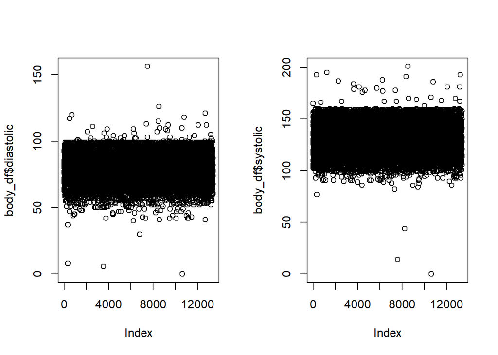

```r
### 혈압이 0인사람 확인
par(mfrow=c(1,2))
plot(body_df$diastolic)
plot(body_df$systolic)
```

```r
### 혈압이 0인 사람 확인
body_df[body_df$diastolic==0 | body_df$systolic==0,]
```

```
##       age gender height_cm weight_kg body.fat_. diastolic systolic gripForce
## 10625  26      F       160     63.56         32         0        0      23.7
##       sit.and.bend.forward_cm sit.ups.counts broad.jump_cm class
## 10625                    17.1             23           128     D
```

```r
### 혈압이 0인 사람 삭제
body_df_clean <- body_df[ - (body_df$diastolic==0 | body_df$systolic==0),]
dim(body_df) ; dim(body_df_clean)
```

```
## [1] 13393    12
```

```
## [1] 13392    12
```

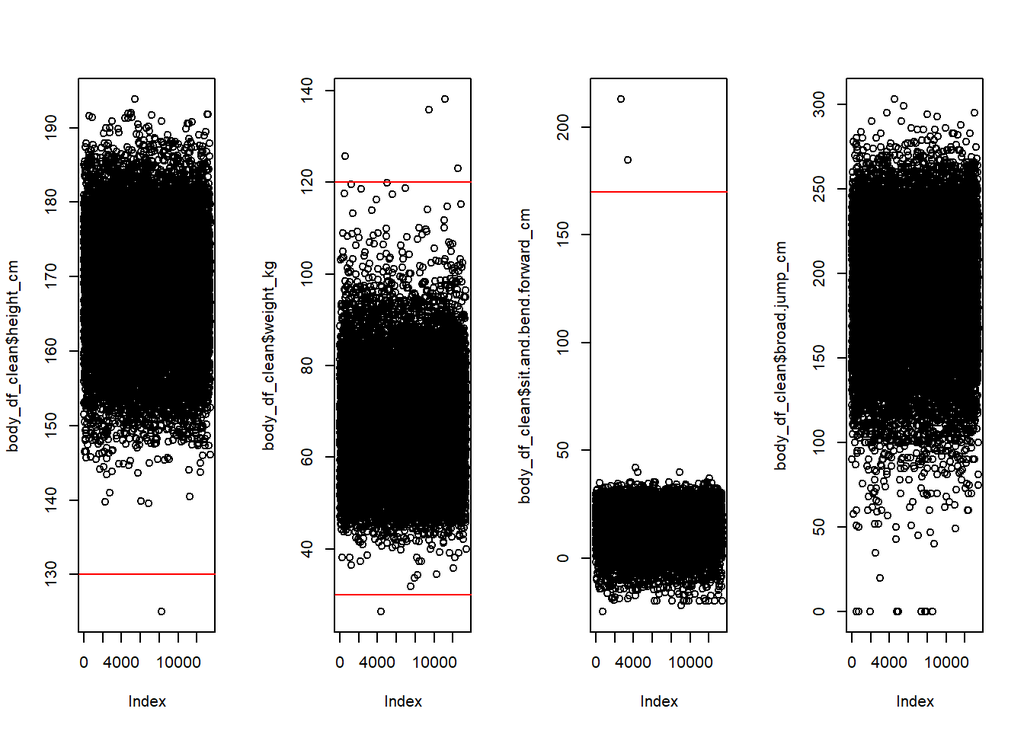

```r
### 키, 몸무게, 앉아서 허리 굽히기, 제자리 멀리뛰기 이상치 확인
par(mfrow=c(1,4))
plot(body_df_clean$height_cm)
abline(h=130,col='red')
plot(body_df_clean$weight_kg)
abline(h=30,col='red')
abline(h=120,col='red')
plot(body_df_clean$sit.and.bend.forward_cm)
abline(h=170,col='red')
plot(body_df_clean$broad.jump_cm)
```

```r
### 예상되는 outlier 확인
body_df_clean[body_df_clean$height_cm <130 |
                body_df_clean$weight_kg <30 |
                body_df_clean$weight_kg >= 120 |
                body_df_clean$sit.and.bend.forward_cm > 170,]
```

```
##       age gender height_cm weight_kg body.fat_. diastolic systolic gripForce
## 555    35      M     191.6    125.70       35.2        85      156      58.0
## 2658   33      M     165.6     60.40       17.8        81      127      38.6
## 3356   45      M     164.4     64.40       24.3        96      142      38.5
## 4371   63      F     153.9     26.30       37.0        73      120      27.2
## 8252   56      F     125.0     34.40       39.2        69      125      12.6
## 9445   22      M     186.2    135.78       35.2        69      141      49.7
## 11146  30      M     190.6    138.10       30.3        82      131      52.3
## 12567  22      M     181.2    123.00       42.7        82      123      41.6
##       sit.and.bend.forward_cm sit.ups.counts broad.jump_cm class
## 555                       9.2             52           228     D
## 2658                    213.0             53           244     B
## 3356                    185.0             44           223     A
## 4371                      7.8              0           105     D
## 8252                     17.0             27           109     B
## 9445                      0.1             26           216     D
## 11146                     4.3             30           181     D
## 12567                     5.0             36           177     D
```

```r
### outlier 삭제
body_df_clean2 <- body_df_clean[body_df_clean$sit.and.bend.forward_cm < 170,]
dim(body_df_clean2)
```

```
## [1] 13390    12
```

## 각 변수별 Plotting

```r
### 패키지 설치 및 불러오기
### install.packages('ggplot2')
### install.packages('gridExtra')
### install.packages('GGally')
library(ggplot2)
library(gridExtra)
### library(GGally)
```

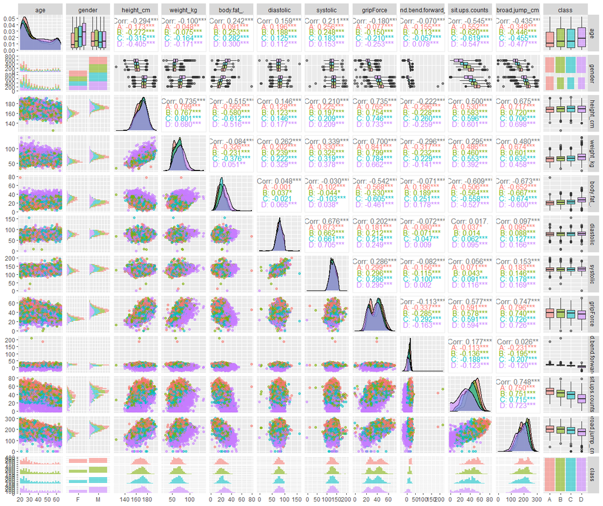

```r
bp_df <- body_df_clean2
## GGally function
# ggpairs(bp_df, aes(colour = class,alpha=0.4))
```

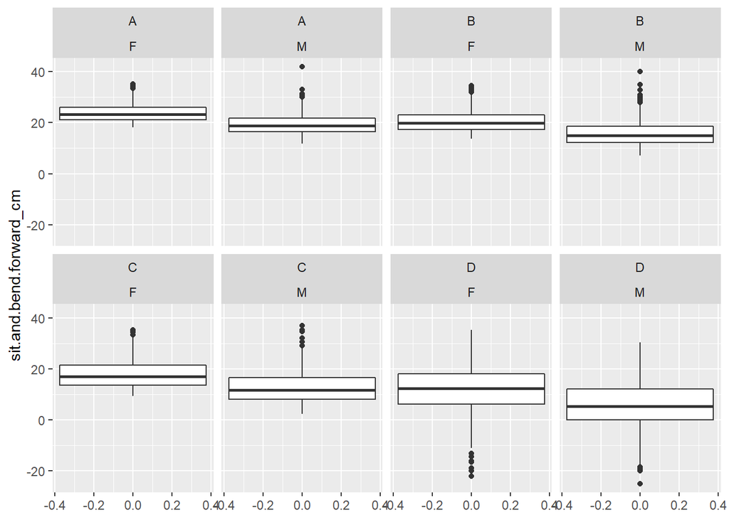

```r
ggplot(bp_df,aes(y=sit.and.bend.forward_cm))+
  geom_boxplot()+
  facet_wrap(vars(class,gender),ncol=4)
```

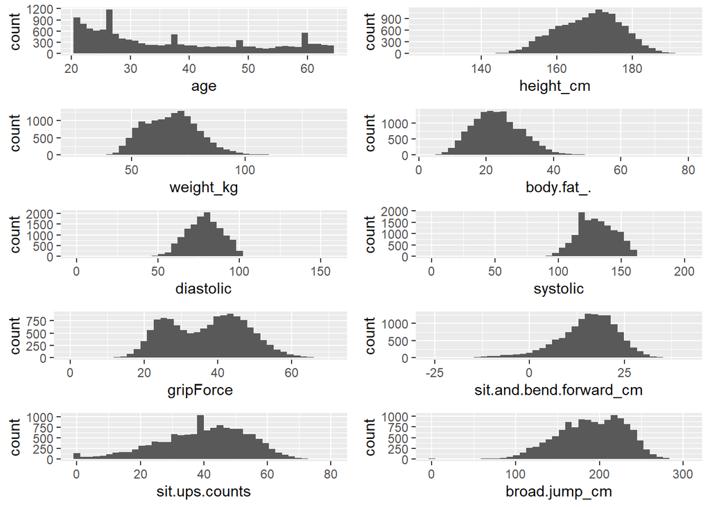

```r
a1<-ggplot(bp_df,aes(age)) + geom_histogram(bins = 40)
a2<-ggplot(bp_df,aes(height_cm)) + geom_histogram(bins = 40)
a3<-ggplot(bp_df,aes(weight_kg)) + geom_histogram(bins = 40)
a4<-ggplot(bp_df,aes(body.fat_.)) + geom_histogram(bins = 40)
a5<-ggplot(bp_df,aes(diastolic)) + geom_histogram(bins = 40)
a6<-ggplot(bp_df,aes(systolic)) + geom_histogram(bins = 40)
a7<-ggplot(bp_df,aes(gripForce)) + geom_histogram(bins = 40)
a8<-ggplot(bp_df,aes(sit.and.bend.forward_cm)) + geom_histogram(bins = 40)
a9<-ggplot(bp_df,aes(sit.ups.counts)) + geom_histogram(bins = 40)
a10<-ggplot(bp_df,aes(broad.jump_cm)) + geom_histogram(bins = 40)
grid.arrange(a1,a2,a3,a4,a5,a6,a7,a8,a9,a10,nrow=5,ncol=2)
```

```r
### class별 count
table(bp_df$class)
```

```
##
##    A    B    C    D
## 3347 3346 3348 3349
```

```r
table(bp_df$class)/ dim(bp_df)[1] * 100
```

```
##
##        A        B        C        D
## 24.99627 24.98880 25.00373 25.01120
```

## 데이터마이닝

### train, test data split

train : test = 7 : 3

```r
train_size <- round(dim(bp_df)[1]*0.7)
set.seed(1234)
train_df_index <- sample(1:dim(bp_df)[1],train_size)
train_df <- bp_df[train_df_index,]
test_df <- bp_df[-train_df_index,]
```

```r
table(train_df$class)
```

```
##
##    A    B    C    D
## 2351 2342 2316 2364
```

```r
table(test_df$class)
```

```
##
##    A    B    C    D
##  996 1004 1032  985
```

```r
# library(dplyr)
# sample_frac(bp_df,size=0.7)
# ?sample_frac
```

```r
### chr type -> factor
str(train_df)
```

```
## 'data.frame':    9373 obs. of  12 variables:
##  $ age                    : num  57 32 22 36 24 25 23 64 29 26 ...
##  $ gender                 : chr  "M" "M" "M" "M" ...
##  $ height_cm              : num  168 171 177 173 180 ...
##  $ weight_kg              : num  68.2 70.8 84.5 70.1 65.6 ...
##  $ body.fat_.             : num  23.3 20.3 9.2 17.2 13.9 16.2 26.4 19.4 11.8 15.1 ...
##  $ diastolic              : num  88 75 58 75 67 62 63 76 96 94 ...
##  $ systolic               : num  142 141 116 128 105 126 108 120 147 123 ...
##  $ gripForce              : num  33.9 38.7 43.9 36.5 41 49.4 27 34.9 60.3 48.6 ...
##  $ sit.and.bend.forward_cm: num  1.4 8.3 14.3 9.3 10.5 26.2 21 13.3 22.2 22.4 ...
##  $ sit.ups.counts         : num  36 49 53 42 45 53 38 34 62 57 ...
##  $ broad.jump_cm          : num  181 196 255 231 215 226 165 184 229 237 ...
##  $ class                  : chr  "D" "C" "B" "B" ...
```

character 자료형 -> factor 자료형

```r
train_df$gender <- as.factor(train_df$gender)
train_df$class <- as.factor(train_df$class)
test_df$gender <- as.factor(test_df$gender)
test_df$class <- as.factor(test_df$class)
str(train_df) ; str(test_df)
```

```
## 'data.frame':    9373 obs. of  12 variables:
##  $ age                    : num  57 32 22 36 24 25 23 64 29 26 ...
##  $ gender                 : Factor w/ 2 levels "F","M": 2 2 2 2 2 2 1 2 2 2 ...
##  $ height_cm              : num  168 171 177 173 180 ...
##  $ weight_kg              : num  68.2 70.8 84.5 70.1 65.6 ...
##  $ body.fat_.             : num  23.3 20.3 9.2 17.2 13.9 16.2 26.4 19.4 11.8 15.1 ...
##  $ diastolic              : num  88 75 58 75 67 62 63 76 96 94 ...
##  $ systolic               : num  142 141 116 128 105 126 108 120 147 123 ...
##  $ gripForce              : num  33.9 38.7 43.9 36.5 41 49.4 27 34.9 60.3 48.6 ...
##  $ sit.and.bend.forward_cm: num  1.4 8.3 14.3 9.3 10.5 26.2 21 13.3 22.2 22.4 ...
##  $ sit.ups.counts         : num  36 49 53 42 45 53 38 34 62 57 ...
##  $ broad.jump_cm          : num  181 196 255 231 215 226 165 184 229 237 ...
##  $ class                  : Factor w/ 4 levels "A","B","C","D": 4 3 2 2 3 1 2 3 1 1 ...
```

```
## 'data.frame':    4017 obs. of  12 variables:
##  $ age                    : num  31 32 28 42 54 42 57 21 25 59 ...
##  $ gender                 : Factor w/ 2 levels "F","M": 2 2 2 1 2 2 1 1 1 1 ...
##  $ height_cm              : num  180 174 174 164 167 ...
##  $ weight_kg              : num  78 71.1 67.7 63.7 67.5 ...
##  $ body.fat_.             : num  20.1 18.4 17.1 32.2 27.6 19.3 20.9 18.9 31.3 30.2 ...
##  $ diastolic              : num  92 76 70 72 85 63 69 78 89 76 ...
##  $ systolic               : num  152 147 127 135 165 110 106 133 128 143 ...
##  $ gripForce              : num  44.8 41.4 43.5 22.7 40.4 43.5 21.5 25.4 25 36.8 ...
##  $ sit.and.bend.forward_cm: num  12 15.2 27.1 0.8 18.6 16 30 20.5 10.7 29.1 ...
##  $ sit.ups.counts         : num  49 53 45 18 34 68 0 36 39 25 ...
##  $ broad.jump_cm          : num  181 219 217 146 148 211 90 137 160 122 ...
##  $ class                  : Factor w/ 4 levels "A","B","C","D": 3 2 2 4 3 1 4 2 3 1 ...
```

### Supervised model training

지도 학습에 필요한 패키지 설치 및 불러오기

```r
### library install
# install.packages('rpart')
# install.packages('rpart.plot')
# install.packages('adabag')
# install.packages('randomForest')
# install.packages('caret')
library(rpart)
library(rpart.plot)
library(adabag)
library(randomForest)
library(caret)
```

최소한의 입력값을 사용하여 모델링

```r
### Default training
########################################################
#################### Tree 기반 모델 ####################
########################################################
### Decision Tree
fit_tree <- rpart(class~.,data = train_df, method='class')
### Bagging Decision Tree
fit_bagging <- bagging(class~., data = train_df)
### Boosting Decision Tree
fit_boosting <- boosting(class~., data = train_df)
### randomforest
fit_rf <- randomForest(class~., data = train_df)
```

각 training의 accuracy는 confusionMatrix함수를 사용하거나 학습된 모델에서 바로 확인할 수 있다.

```r
#### training accuracy

pred_tree<-predict(fit_tree,type='class')
pred_bagging <- predict(fit_bagging,newdata = train_df, type='class')
pred_boosting <- predict(fit_boosting,newdata = train_df, type='class')
pred_rf <- predict(fit_rf,type='class')

#####
### confusionMatrix(예측한 값, 실제값)
tree_accuracy <- confusionMatrix(pred_tree, train_df$class)[["overall"]][["Accuracy"]]
bagging_accuracy <- confusionMatrix(factor(pred_bagging$class), train_df$class)[["overall"]][["Accuracy"]]
boosting_accuracy <- confusionMatrix(factor(pred_boosting$class), train_df$class)[["overall"]][["Accuracy"]]
rf_accuracy <- confusionMatrix(pred_rf, train_df$class)[["overall"]][["Accuracy"]]
tree_accuracy ; bagging_accuracy ; boosting_accuracy ; rf_accuracy
```

```
## [1] 0.5651339
```

```
## [1] 0.6062093
```

```
## [1] 0.6191187
```

```
## [1] 0.7349835
```

### Feature Importance

Tree 기반 모델을 사용하는 이유 중 feature importance를 확인할 수 있다.

feature importance의 값이 높을수록 그 변수가 중요하다.

```r
### feature important
a <- data.frame('feature'=names(fit_tree$variable.importance),'tree_FI'=fit_tree$variable.importance)
b <- data.frame('feature'=names(fit_bagging$importance), 'bagging_FI'=fit_bagging$importance)
c <- data.frame('feature'=names(fit_boosting$importance), 'boosting_FI' = fit_boosting$importance)
d <- data.frame('feature'=rownames(fit_rf$importance), 'rf_FI' = as.numeric(fit_rf$importance))
ab <- merge(a,b,key='feature')
cd <- merge(c,d,key='feature')
abcd <- merge(ab,cd,key='feature')
abcd
```

```
##                    feature     tree_FI bagging_FI boosting_FI      rf_FI
## 1                      age   42.650092  0.7374912   0.9020553  609.73333
## 2               body.fat_.  272.723873 11.6128232  10.9426085  690.29464
## 3            broad.jump_cm  244.413123  0.2899935   0.2489401  529.00457
## 4                diastolic    5.081581  0.0000000   0.0000000  338.27047
## 5                   gender  180.835916  0.6759026   0.5899665   99.44484
## 6                gripForce  218.248379  0.6628677   1.3603330  572.33774
## 7                height_cm  167.304058  0.0000000   0.0000000  454.23964
## 8  sit.and.bend.forward_cm 1275.096018 68.2253849  67.1623814 1806.16400
## 9           sit.ups.counts  414.680676 16.3886515  16.6271287  933.61180
## 10               weight_kg  123.523705  1.4068855   2.1665864  628.61090
```

```r
#### 순위를 매겨 변수중요도를 확인해보자
abcd2 <- abcd
abcd2$tree_FI <- rank(-abcd$tree_FI)
abcd2$bagging_FI <- rank(-abcd$bagging_FI)
abcd2$boosting_FI <- rank(-abcd$boosting_FI)
abcd2$rf_FI <- rank(-abcd$rf_FI)
abcd2
```

```
##                    feature tree_FI bagging_FI boosting_FI rf_FI
## 1                      age       9        5.0         6.0     5
## 2               body.fat_.       3        3.0         3.0     3
## 3            broad.jump_cm       4        8.0         8.0     7
## 4                diastolic      10        9.5         9.5     9
## 5                   gender       6        6.0         7.0    10
## 6                gripForce       5        7.0         5.0     6
## 7                height_cm       7        9.5         9.5     8
## 8  sit.and.bend.forward_cm       1        1.0         1.0     1
## 9           sit.ups.counts       2        2.0         2.0     2
## 10               weight_kg       8        4.0         4.0     4
```

### Tree Plotting

간단하게 트리모델을 plotting할 수 있다.

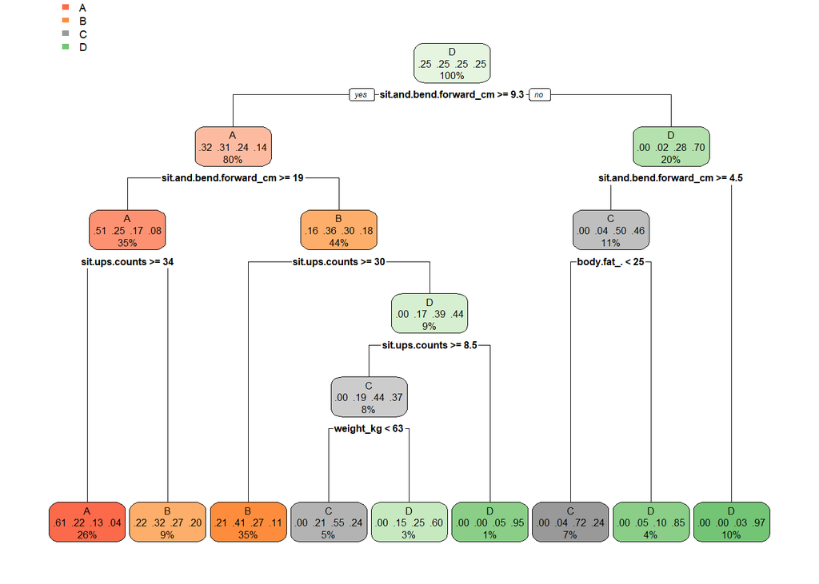

```r
rpart.plot(fit_tree)
```

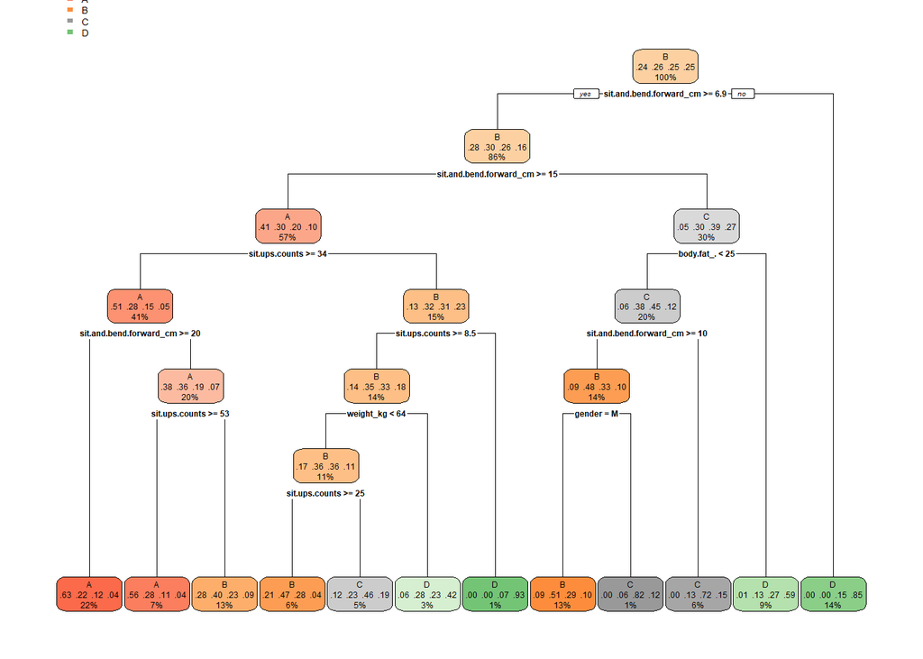

```r
rpart.plot(fit_bagging$tree[[10]])
```

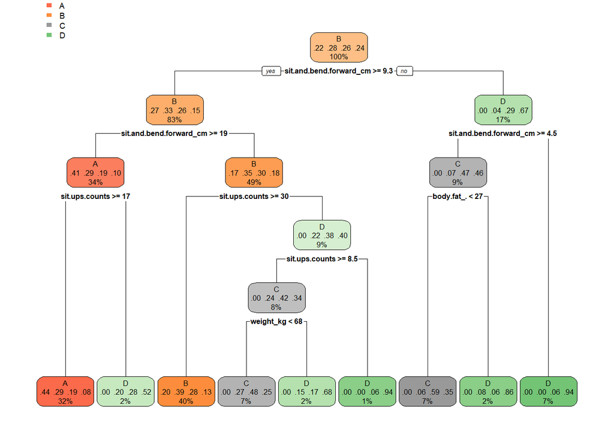

```r
rpart.plot(fit_boosting$tree[[10]])
```

### K-Nearest Neighbor classification

K개를 설정해야 되는 Model

K는 같은 class로 볼 데이터의 수이다.

K = HyperParameter(초모수)

```r
### install.packages(caret)
library(caret)
```

```r
fit_knn <- train(class~.,
                 data = train_df,
                 method = 'knn',
                 tuneLength = 4)
fit_knn
```

```
## k-Nearest Neighbors
##
## 9373 samples
##   11 predictor
##    4 classes: 'A', 'B', 'C', 'D'
##
## No pre-processing
## Resampling: Bootstrapped (25 reps)
## Summary of sample sizes: 9373, 9373, 9373, 9373, 9373, 9373, ...
## Resampling results across tuning parameters:
##
##   k   Accuracy   Kappa
##    5  0.5207220  0.3609836
##    7  0.5348626  0.3798427
##    9  0.5416833  0.3889242
##   11  0.5474490  0.3966179
##
## Accuracy was used to select the optimal model using the largest value.
## The final value used for the model was k = 11.
```

```r
fit_knn2 <- train(class~.,
                 data = train_df,
                 method = 'knn',
                 tuneLength = 10)
fit_knn2
```

```
## k-Nearest Neighbors
##
## 9373 samples
##   11 predictor
##    4 classes: 'A', 'B', 'C', 'D'
##
## No pre-processing
## Resampling: Bootstrapped (25 reps)
## Summary of sample sizes: 9373, 9373, 9373, 9373, 9373, 9373, ...
## Resampling results across tuning parameters:
##
##   k   Accuracy   Kappa
##    5  0.5209847  0.3613040
##    7  0.5325872  0.3767743
##    9  0.5407510  0.3876599
##   11  0.5457810  0.3943562
##   13  0.5503113  0.4004063
##   15  0.5548554  0.4064666
##   17  0.5586937  0.4115743
##   19  0.5604837  0.4139543
##   21  0.5623432  0.4164505
##   23  0.5628029  0.4170709
##
## Accuracy was used to select the optimal model using the largest value.
## The final value used for the model was k = 23.
```

```r
fit_knn3 <- train(class~.,
                 data = train_df,
                 method = 'knn',
                 tuneGrid=expand.grid(k=c(80,81,82)))
fit_knn3
```

```
## k-Nearest Neighbors
##
## 9373 samples
##   11 predictor
##    4 classes: 'A', 'B', 'C', 'D'
##
## No pre-processing
## Resampling: Bootstrapped (25 reps)
## Summary of sample sizes: 9373, 9373, 9373, 9373, 9373, 9373, ...
## Resampling results across tuning parameters:
##
##   k   Accuracy   Kappa
##   80  0.5600987  0.4136311
##   81  0.5592355  0.4124824
##   82  0.5593510  0.4126407
##
## Accuracy was used to select the optimal model using the largest value.
## The final value used for the model was k = 80.
```

### Support Vector Machine(SVM)

svm에서 사용되는 초모수는 C이다.

C가 작을수록 margin에서 오분류를 허용하며, C가 클수록 margin에서 오분류에서 허용을 하지 않는다.

```r
fit_svm <- train(class~.,
                 data = train_df,
                 method = 'svmLinear',
                 tuneGrid = expand.grid(C = c(0.1,1,10)))
fit_svm
```

```
## Support Vector Machines with Linear Kernel
##
## 9373 samples
##   11 predictor
##    4 classes: 'A', 'B', 'C', 'D'
##
## No pre-processing
## Resampling: Bootstrapped (25 reps)
## Summary of sample sizes: 9373, 9373, 9373, 9373, 9373, 9373, ...
## Resampling results across tuning parameters:
##
##   C     Accuracy   Kappa
##    0.1  0.6274767  0.5031756
##    1.0  0.6275330  0.5032443
##   10.0  0.6277185  0.5034896
##
## Accuracy was used to select the optimal model using the largest value.
## The final value used for the model was C = 10.
```

```r
fit_svm2 <- train(class~.,
                  data = train_df,
                  method = 'svmLinear',
                  tuneGrid =expand.grid(C = c(6,8,10,20,30)))
fit_svm2
```

```
## Support Vector Machines with Linear Kernel
##
## 9373 samples
##   11 predictor
##    4 classes: 'A', 'B', 'C', 'D'
##
## No pre-processing
## Resampling: Bootstrapped (25 reps)
## Summary of sample sizes: 9373, 9373, 9373, 9373, 9373, 9373, ...
## Resampling results across tuning parameters:
##
##   C   Accuracy   Kappa
##    6  0.6284418  0.5046030
##    8  0.6285462  0.5047424
##   10  0.6284885  0.5046659
##   20  0.6283830  0.5045259
##   30  0.6283842  0.5045272
##
## Accuracy was used to select the optimal model using the largest value.
## The final value used for the model was C = 8.
```

```r
svm_accuracy <- max(fit_svm[["results"]][["Accuracy"]])
knn_accuracy <- max(fit_knn2[['results']][['Accuracy']])
```

### test accuracy 확인

앞에서 학습한 모델들의 정확도를 확인한다.

```r
tree_accuracy
```

```
## [1] 0.5651339
```

```r
bagging_accuracy
```

```
## [1] 0.6062093
```

```r
boosting_accuracy
```

```
## [1] 0.6191187
```

```r
rf_accuracy
```

```
## [1] 0.7349835
```

```r
knn_accuracy
```

```
## [1] 0.5628029
```

```r
svm_accuracy
```

```
## [1] 0.6277185
```

```r
tree_test_accuracy <- confusionMatrix(predict(fit_tree,newdata = test_df, type='class'), test_df$class)[["overall"]][["Accuracy"]]
pred_bagging <- predict(fit_bagging,newdata = test_df,type='class')
bagging_test_accuracy <- confusionMatrix(as.factor(pred_bagging$class), test_df$class)[["overall"]][["Accuracy"]]
pred_boosting <- predict(fit_boosting, newdata = test_df, type = 'class')
boosting_test_accuracy <- confusionMatrix(as.factor(pred_boosting$class), test_df$class)[["overall"]][["Accuracy"]]
rf_test_accuracy <- confusionMatrix(predict(fit_rf,newdata = test_df, type='class'), test_df$class)[["overall"]][["Accuracy"]]
knn_test_accuracy <- confusionMatrix(predict(fit_knn2,newdata = test_df), test_df$class)[["overall"]][["Accuracy"]]
svm_test_accuracy <- confusionMatrix(predict(fit_svm,newdata = test_df), test_df$class)[["overall"]][["Accuracy"]]
```

```r
train_test_accuracy_df <-data.frame('train_accuracy'= c(tree_accuracy,bagging_accuracy,boosting_accuracy,
                              rf_accuracy,knn_accuracy,svm_accuracy),
           'test_accuracy' = c(tree_test_accuracy,bagging_test_accuracy,boosting_test_accuracy,
                               rf_test_accuracy,knn_test_accuracy,svm_test_accuracy),
           row.names = c('Tree','Bagging','Boosting','RandomForest','knn','svm'))
train_test_accuracy_df
```

```
##              train_accuracy test_accuracy
## Tree              0.5651339     0.5416978
## Bagging           0.6062093     0.5952203
## Boosting          0.6191187     0.6019417
## RandomForest      0.7349835     0.7266617
## knn               0.5628029     0.5937267
## svm               0.6277185     0.6141399
```

Tree 기반 모델에서는 RandomForest 모델이 가장 정확도가 높게 나온것을 확인할 수 있다.

Tree 기반인 아닌 모델에서는 svm 모델이 가장 정확도가 높다.

회귀분석에서처럼 Stepwise와 같은 방법을 적용한다면 정확도를 높일 수 있는지 확인해보자.

```r
abcd2
```

```
##                    feature tree_FI bagging_FI boosting_FI rf_FI
## 1                      age       9        5.0         6.0     5
## 2               body.fat_.       3        3.0         3.0     3
## 3            broad.jump_cm       4        8.0         8.0     7
## 4                diastolic      10        9.5         9.5     9
## 5                   gender       6        6.0         7.0    10
## 6                gripForce       5        7.0         5.0     6
## 7                height_cm       7        9.5         9.5     8
## 8  sit.and.bend.forward_cm       1        1.0         1.0     1
## 9           sit.ups.counts       2        2.0         2.0     2
## 10               weight_kg       8        4.0         4.0     4
```

```r
abcd2$total_rank <-rank(rowSums(sapply(abcd2,as.numeric)[,2:5]))
```

```r
### rank 5등까지 변수 뽑기
abcd2[abcd2$total_rank <=5,]['feature']
```

```
##                    feature
## 2               body.fat_.
## 6                gripForce
## 8  sit.and.bend.forward_cm
## 9           sit.ups.counts
## 10               weight_kg
```

### 최종 모형과 주요 변수 선정

최종 모형 : RandomForest, svm

주요 변수 : body.fat_., gripForce, sit.and.bend.forward_cm, sit.ups.counts, weight_kg

#### 사용되지 않는 변수 진단.

```r
train_df[(train_df$class =='A') & (train_df$age >=60),][1:20,]
```

```
##       age gender height_cm weight_kg body.fat_. diastolic systolic gripForce
## 2375   64      F     149.4      55.0       33.2        91      152      23.0
## 3292   63      M     167.6      65.4       18.3        76      152      40.3
## 4769   61      M     166.9      69.3       20.1        72      160      46.2
## 7071   62      M     170.0      72.7       22.5        95      145      42.5
## 8386   60      M     165.4      67.7       18.2        90      159      43.4
## 2761   62      M     167.0      61.8       10.2        70      119      40.9
## 3351   60      M     175.7      72.1       26.5        74      137      47.2
## 12902  63      F     160.9      52.1       27.2        74      120      22.7
## 6468   61      M     172.1      76.0       29.9        97      154      41.7
## 6880   63      F     153.1      53.0       30.2        63      103      22.1
## 5085   64      F     152.0      62.1       33.7        62      116      29.4
## 10146  62      F     158.3      58.8       28.3        80      128      26.7
## 3741   60      M     171.4      68.4       17.1        72      110      35.6
## 11154  60      M     168.7      67.9       10.5        64      128      47.0
```

[output cut: 27 more lines]

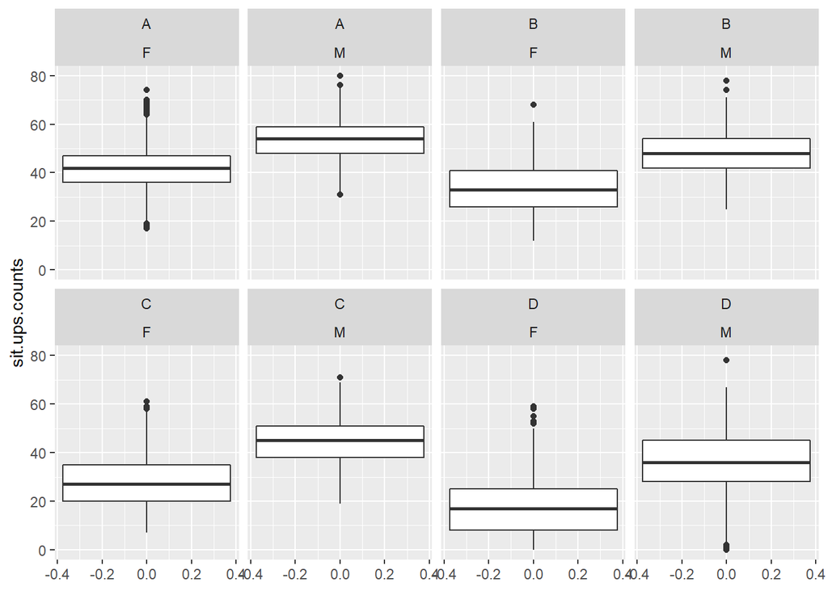

```r
ggplot(bp_df,aes(y=sit.ups.counts))+
  geom_boxplot()+
  facet_wrap(vars(class,gender),ncol=4)
```

age, gender, height, weight, diastolic, systolic 변수을 버리기가 아깝다.

비지도 학습(Unsupervised learning) 또는 군집 분석(cluster analysis)을 통해 사용할 방법을 강구해보자.

### 계층 군집 분석(Hierarical cluster analysis)

```r
cluster_df <- bp_df[,c('age','gender','height_cm','weight_kg','diastolic','systolic')]
head(cluster_df)
```

```
##   age gender height_cm weight_kg diastolic systolic
## 2  25      M     165.0      55.8        77      126
## 3  31      M     179.6      78.0        92      152
## 4  32      M     174.5      71.1        76      147
## 5  28      M     173.8      67.7        70      127
## 6  36      F     165.4      55.4        64      119
## 7  42      F     164.5      63.7        72      135
```

$BMI = 체중(kg) / 신장(m)^2$, 파생변수 생성

```r
cluster_df$bmi <- cluster_df$weight_kg / (cluster_df$height_cm*0.01)^2
```

```r
cluster_df <- subset(cluster_df, select = -c(weight_kg,height_cm))
head(cluster_df)
```

```
##   age gender diastolic systolic      bmi
## 2  25      M        77      126 20.49587
## 3  31      M        92      152 24.18143
## 4  32      M        76      147 23.34956
## 5  28      M        70      127 22.41244
## 6  36      F        64      119 20.25064
## 7  42      F        72      135 23.54006
```

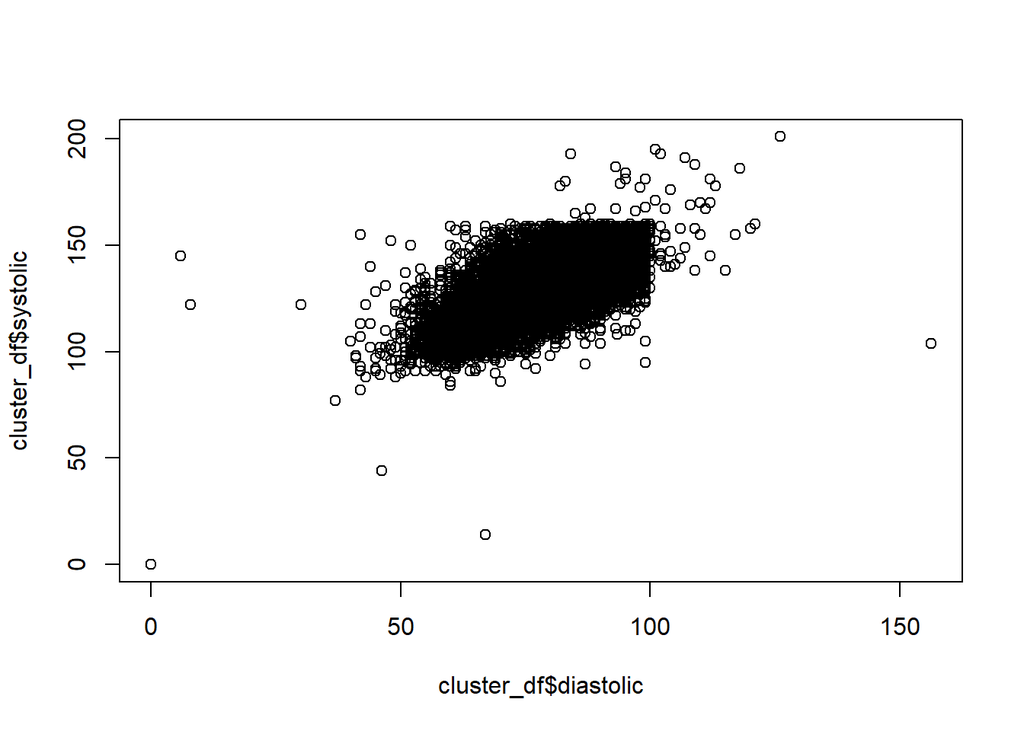

```r
plot(cluster_df$diastolic, cluster_df$systolic)
```

```r
cor(cluster_df$diastolic, cluster_df$systolic)
```

```
## [1] 0.6763
```

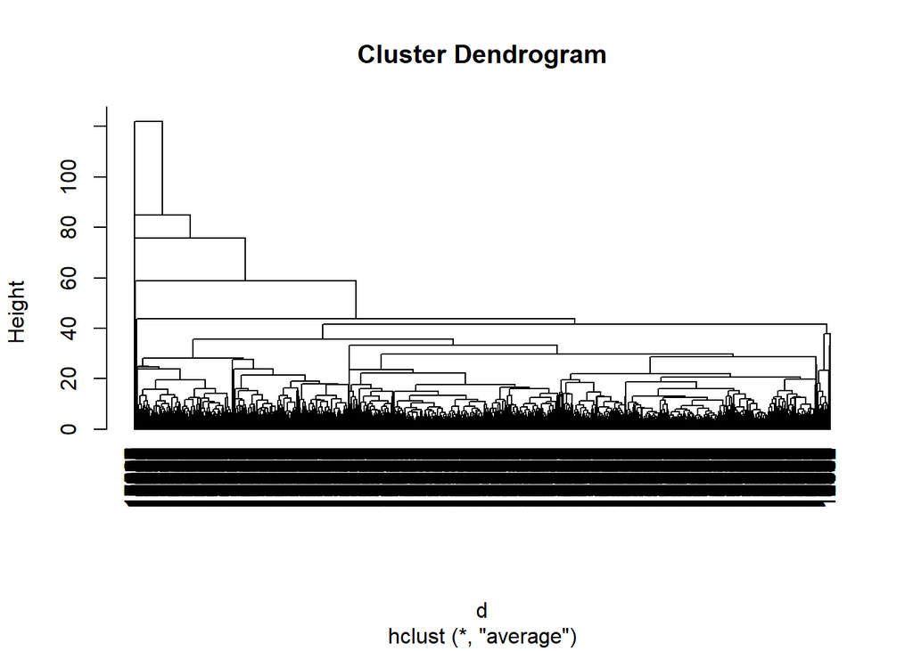

```r
cluster_df$gender <- ifelse(cluster_df$gender == 'M',0,1)
d <- dist(cluster_df,method = 'euclidean')
fit_hier <- hclust(d,method='ave')
plot(fit_hier,hang=-1)
```

```r
hier_cluster_result<-cutree(fit_hier,h=30)
table(hier_cluster_result)
```

```
## hier_cluster_result
##    1    2    3    4    5    6    7    8    9   10   11   12   13   14   15   16
## 9003 4083   23  244    2    1    8    6    4    9    2    1    1    1    1    1
```

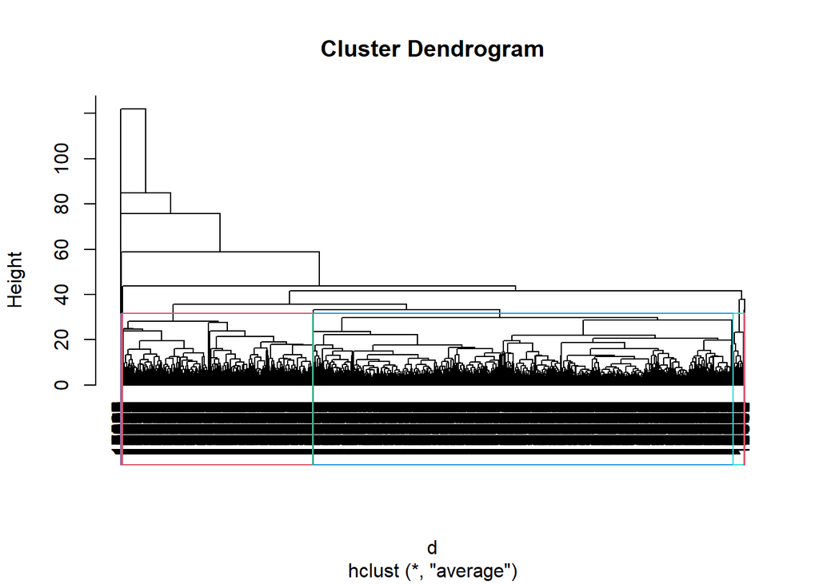

```r
plot(fit_hier,hang=-1)
rect.hclust(fit_hier,h=30,border=2:6)
```

```r
cluster_df$hier_cluster_num <- hier_cluster_result
head(cluster_df)
```

```
##   age gender diastolic systolic      bmi hier_cluster_num
## 2  25      0        77      126 20.49587                1
## 3  31      0        92      152 24.18143                1
## 4  32      0        76      147 23.34956                1
## 5  28      0        70      127 22.41244                1
## 6  36      1        64      119 20.25064                1
## 7  42      1        72      135 23.54006                2
```

```r
# install.packages('NbClust')
# cluster_df$gender <- ifelse(cluster_df$gender == 'M',0,1)
# library(NbClust)
# fit_nc <- NbClust(cluster_df,distance='euclidean',min.nc = 2, max.nc=30,method='avergae')
```

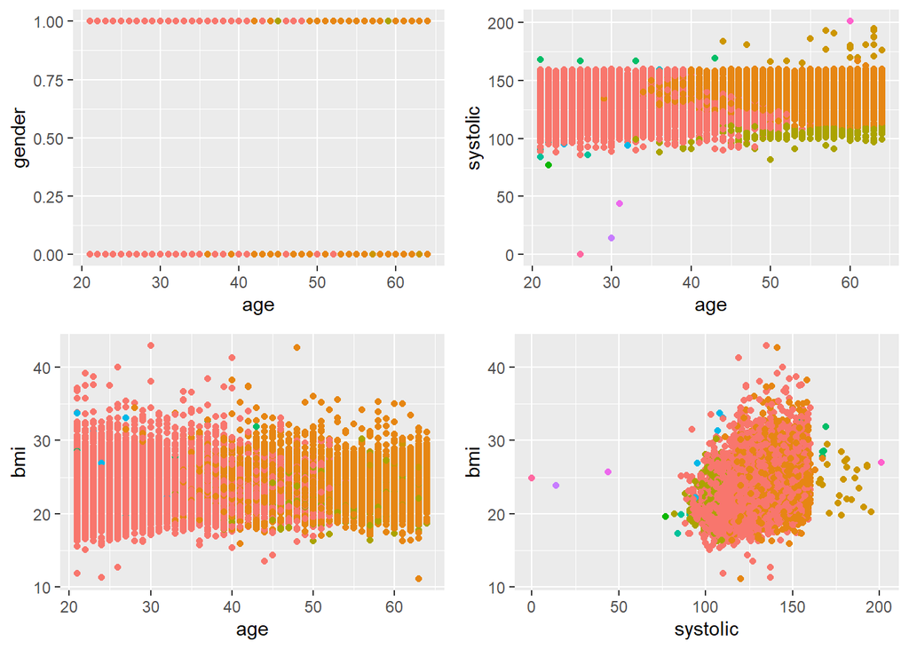

```r
b1 <- ggplot(cluster_df, aes(age,gender,group=factor(hier_cluster_num),col=factor(hier_cluster_num))) + geom_point() + theme(legend.position='none')
b2 <- ggplot(cluster_df, aes(age,systolic,group=factor(hier_cluster_num),col=factor(hier_cluster_num))) + geom_point() + theme(legend.position='none')
b3 <- ggplot(cluster_df, aes(age,bmi,group=factor(hier_cluster_num),col=factor(hier_cluster_num))) + geom_point() + theme(legend.position='none')
b4 <- ggplot(cluster_df, aes(systolic,bmi,group=factor(hier_cluster_num),col=factor(hier_cluster_num))) + geom_point() + theme(legend.position='none')
grid.arrange(b1,b2,b3,b4,nrow=2,ncol=2)
```

```r
library(dplyr)
fit_kmeans <- kmeans(cluster_df,12)
```

```r
cluster_df$kmeans_cluster_num <-fit_kmeans$cluster
```

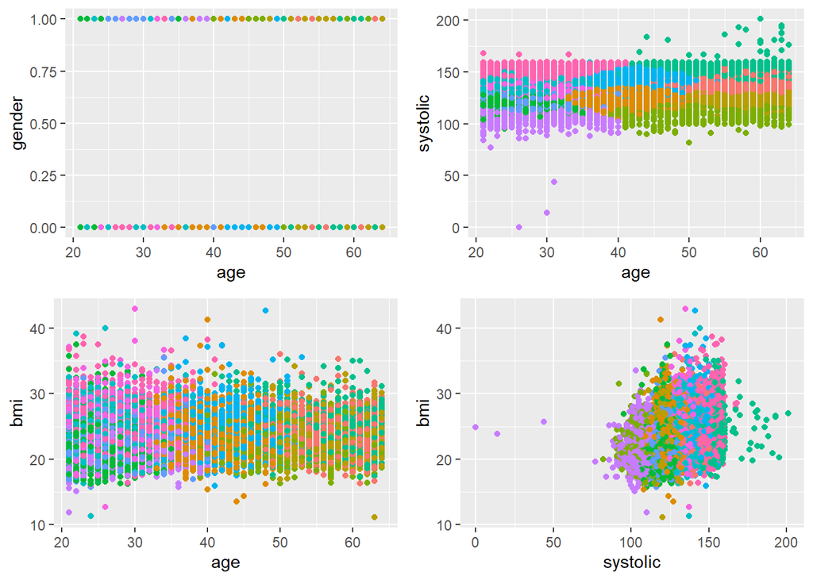

```r
c1 <- ggplot(cluster_df, aes(age,gender,group=factor(kmeans_cluster_num),col=factor(kmeans_cluster_num))) + geom_point() + theme(legend.position='none')
c2 <- ggplot(cluster_df, aes(age,systolic,group=factor(kmeans_cluster_num),col=factor(kmeans_cluster_num))) + geom_point() + theme(legend.position='none')
c3 <- ggplot(cluster_df, aes(age,bmi,group=factor(kmeans_cluster_num),col=factor(kmeans_cluster_num))) + geom_point() + theme(legend.position='none')
c4 <- ggplot(cluster_df, aes(systolic,bmi,group=factor(kmeans_cluster_num),col=factor(kmeans_cluster_num))) + geom_point() + theme(legend.position='none')
grid.arrange(c1,c2,c3,c4,nrow=2,ncol=2)
```

### 군집분석시 주의할점

거리기반 군집분석일 경우 단위에 굉장히 민감하다.

ex) a = (1,2,3,4,5)(단위:m), b = (100,200,300,400,500)(단위:cm)

같은 단위를 가지는 변수일 경우 상관이 없지만 다른 단위를 가지는 변수가 존재하는 경우

scaling을 통해 단위를 없애준다.

```r
### 정규화(Normalization)
scale_clsuter_df <- cluster_df[,1:5]
scale_cluster_df <- scale(scale_clsuter_df)
scale_cluster_df <- data.frame(scale_cluster_df)
```

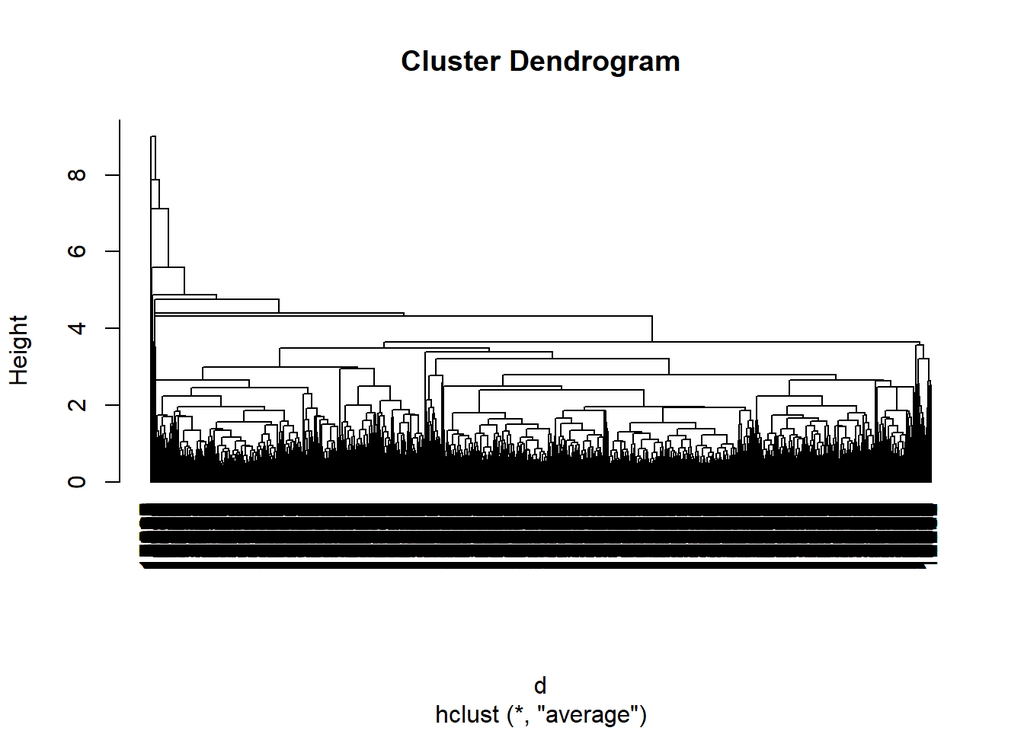

```r
d <- dist(scale_cluster_df,method = 'euclidean')
fit_hier <- hclust(d,method='ave')
plot(fit_hier,hang=-1)
```

```r
hier_cluster_result<-cutree(fit_hier,h=4)
cluster_df$scale_hier_cluster_num <- hier_cluster_result
table(hier_cluster_result)
```

```
## hier_cluster_result
##     1     2     3     4     5     6     7     8     9    10
## 13310    34     2    15    10    14     1     2     1     1
```

```r
fit_kmeans <- kmeans(scale_cluster_df,12)
cluster_df$scale_kmeans_cluster_num <-fit_kmeans$cluster
```

```r
head(cluster_df[,c("hier_cluster_num","scale_hier_cluster_num")],20)
```

```
##    hier_cluster_num scale_hier_cluster_num
## 2                 1                      1
## 3                 1                      1
## 4                 1                      1
## 5                 1                      1
## 6                 1                      1
## 7                 2                      1
## 8                 1                      1
## 9                 3                      1
## 10                1                      1
## 11                1                      1
## 12                4                      1
## 13                1                      1
## 14                1                      1
## 15                1                      1
## 16                2                      1
## 17                1                      1
## 18                1                      1
## 19                1                      1
## 20                1                      1
## 21                1                      1
```

```r
head(cluster_df[,c("kmeans_cluster_num","scale_kmeans_cluster_num")],20)
```

```
##    kmeans_cluster_num scale_kmeans_cluster_num
## 2                   5                       12
## 3                  12                       10
## 4                   7                       12
## 5                   9                        4
## 6                   9                        2
## 7                   2                        5
## 8                  11                       10
## 9                   6                        6
## 10                 12                       10
## 11                  4                        4
## 12                  4                        5
## 13                  9                        2
## 14                 10                        4
## 15                  5                        7
## 16                  8                       11
## 17                  5                        3
## 18                  7                        4
## 19                  9                        4
## 20                  7                        3
## 21                 11                        3
```

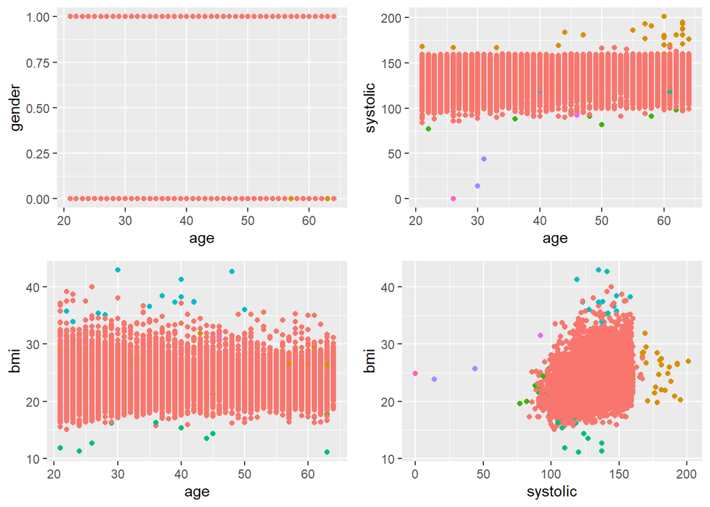

```r
b1 <- ggplot(cluster_df, aes(age,gender,group=factor(scale_hier_cluster_num),col=factor(scale_hier_cluster_num))) + geom_point() + theme(legend.position='none')
b2 <- ggplot(cluster_df, aes(age,systolic,group=factor(scale_hier_cluster_num),col=factor(scale_hier_cluster_num))) + geom_point() + theme(legend.position='none')
b3 <- ggplot(cluster_df, aes(age,bmi,group=factor(scale_hier_cluster_num),col=factor(scale_hier_cluster_num))) + geom_point() + theme(legend.position='none')
b4 <- ggplot(cluster_df, aes(systolic,bmi,group=factor(scale_hier_cluster_num),col=factor(scale_hier_cluster_num))) + geom_point() + theme(legend.position='none')
grid.arrange(b1,b2,b3,b4,nrow=2,ncol=2)
```

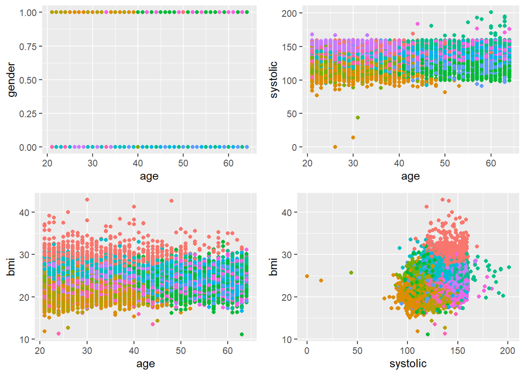

```r
c1 <- ggplot(cluster_df, aes(age,gender,group=factor(scale_kmeans_cluster_num),col=factor(scale_kmeans_cluster_num))) + geom_point()+ theme(legend.position='none')
c2 <- ggplot(cluster_df, aes(age,systolic,group=factor(scale_kmeans_cluster_num),col=factor(scale_kmeans_cluster_num))) + geom_point()+ theme(legend.position='none')
c3 <- ggplot(cluster_df, aes(age,bmi,group=factor(scale_kmeans_cluster_num),col=factor(scale_kmeans_cluster_num))) + geom_point()+ theme(legend.position='none')
c4 <- ggplot(cluster_df, aes(systolic,bmi,group=factor(scale_kmeans_cluster_num),col=factor(scale_kmeans_cluster_num))) + geom_point()+ theme(legend.position='none')
grid.arrange(c1,c2,c3,c4,nrow=2,ncol=2)
```

```r
head(cluster_df)
```

```
##   age gender diastolic systolic      bmi hier_cluster_num kmeans_cluster_num
## 2  25      0        77      126 20.49587                1                  5
## 3  31      0        92      152 24.18143                1                 12
## 4  32      0        76      147 23.34956                1                  7
## 5  28      0        70      127 22.41244                1                  9
## 6  36      1        64      119 20.25064                1                  9
## 7  42      1        72      135 23.54006                2                  2
##   scale_hier_cluster_num scale_kmeans_cluster_num
## 2                      1                       12
## 3                      1                       10
## 4                      1                       12
## 5                      1                        4
## 6                      1                        2
## 7                      1                        5
```

```r
table(cluster_df$scale_hier_cluster_num)
```

```
##
##     1     2     3     4     5     6     7     8     9    10
## 13310    34     2    15    10    14     1     2     1     1
```

```r
table(cluster_df$scale_kmeans_cluster_num)
```

```
##
##    1    2    3    4    5    6    7    8    9   10   11   12
##  600 1291 1575 1168 1060  785 1411  964  720 1450  887 1479
```

### 최종 모형 도출

최종 모형 : RandomForest, svm

주요 변수 : body.fat_., gripForce, sit.and.bend.forward_cm, sit.ups.counts, weight_kg

추가 변수 : scale_kmeans_cluster_num

```r
final_df <- cbind(bp_df,cluster_df$scale_kmeans_cluster_num)
final_df <- select(final_df,-c(age,gender,height_cm,diastolic,systolic,broad.jump_cm))
colnames(final_df)[7] <- c('scale_kmeans_cluster_num')
colnames(train_df)
```

```
##  [1] "age"                     "gender"
##  [3] "height_cm"               "weight_kg"
##  [5] "body.fat_."              "diastolic"
##  [7] "systolic"                "gripForce"
##  [9] "sit.and.bend.forward_cm" "sit.ups.counts"
## [11] "broad.jump_cm"           "class"
```

```r
train_df <- final_df[train_df_index,]
test_df <- final_df[-train_df_index,]

train_df$class <- as.factor(train_df$class)
train_df$scale_kmeans_cluster_num <- as.factor(train_df$scale_kmeans_cluster_num)

test_df$class <- as.factor(test_df$class)
test_df$scale_kmeans_cluster_num <- as.factor(test_df$scale_kmeans_cluster_num)

final_rf_result <- randomForest(class~weight_kg + body.fat_.+gripForce+sit.and.bend.forward_cm+sit.ups.counts,data=train_df)

final_rf_result2 <- randomForest(class~weight_kg + body.fat_.+gripForce+sit.and.bend.forward_cm+sit.ups.counts + scale_kmeans_cluster_num,data=train_df)


final_svm_result <- train(class~weight_kg + body.fat_.+gripForce+sit.and.bend.forward_cm+sit.ups.counts,
                          data = train_df,
                          method = 'svmLinear',
                          tuneGrid = expand.grid(C = c(0.1,1,10)))


final_svm_result2 <- train(class~.,
                 data = train_df,
                 method = 'svmLinear',
                 tuneGrid = expand.grid(C = c(0.1,1,10)))
```

```r
### randomforest feature importance best5
rf_fi_tr <- confusionMatrix(final_rf_result$predicted, train_df$class)[["overall"]][["Accuracy"]]

rf_fi_te <- confusionMatrix(predict(final_rf_result,newdata=test_df,type='class'),test_df$class)[["overall"]][["Accuracy"]]

### randomforest feature importance best5 + scale_kmeans_cluster_num
rf_fis_tr <- confusionMatrix(final_rf_result2$predicted,train_df$class)[["overall"]][["Accuracy"]]

rf_fis_te <- confusionMatrix(predict(final_rf_result2,newdata=test_df,type='class'),test_df$class)[["overall"]][["Accuracy"]]

### svm feature importance best5
svm_fi_tr <- max(final_svm_result[["results"]][["Accuracy"]])

svm_fi_te <- confusionMatrix(predict(final_svm_result,newdata = test_df), test_df$class)[["overall"]][["Accuracy"]]

### svm feature importance best5 + scale_kmeans_cluster_num
svm_fis_tr <- max(final_svm_result2[["results"]][["Accuracy"]])

svm_fis_te <- confusionMatrix(predict(final_svm_result2,newdata = test_df), test_df$class)[["overall"]][["Accuracy"]]
train_test_accuracy_df2 <-data.frame('train_accuracy'= c(rf_fi_tr,rf_fis_tr,svm_fi_tr,svm_fis_tr),
           'test_accuracy' = c(rf_fi_te,rf_fis_te,svm_fi_te,svm_fis_te),
           row.names = c('rf_best5','rf_best5_cluster','svm_best5','svm_best5_cluster'))
train_test_accuracy_df2
```

```
##                   train_accuracy test_accuracy
## rf_best5               0.6324549     0.6338063
## rf_best5_cluster       0.6704364     0.6659198
## svm_best5              0.5802238     0.5698282
## svm_best5_cluster      0.5976202     0.5877521
```

정확도가 더 떨어진 것을 확인할 수 있다.

### 도메인을 활용하여 모델링 하기

```r
bp_df$gender <- as.factor(bp_df$gender)
bp_df$class <- as.factor(bp_df$class)
bp_df_m <- bp_df[bp_df$gender == 'M',]
bp_df_f <- bp_df[bp_df$gender != 'M',]
bp_df_m <- bp_df_m[,-2]
bp_df_f <- bp_df_f[,-2]
```

```r
train_m_size <- round(dim(bp_df_m)[1]*0.7)
train_f_size <- round(dim(bp_df_f)[1]*0.7)
set.seed(1004)
train_m_df_index <- sample(1:dim(bp_df_m)[1],train_m_size)
train_f_df_index <- sample(1:dim(bp_df_f)[1],train_f_size)

train_m_df <- bp_df_m[train_m_df_index,]
test_m_df <- bp_df_m[-train_m_df_index,]

train_f_df <- bp_df_f[train_f_df_index,]
test_f_df <- bp_df_f[-train_f_df_index,]
```

```r
fit_train_m <- randomForest(class~.,data = train_m_df)
fit_train_f <- randomForest(class~.,data = train_f_df)
```

```r
tr <- sum(diag(confusionMatrix(fit_train_m$predicted, train_m_df$class)[["table"]] + confusionMatrix(fit_train_f$predicted, train_f_df$class)[["table"]]))/ sum(confusionMatrix(fit_train_m$predicted, train_m_df$class)[["table"]] + confusionMatrix(fit_train_f$predicted, train_f_df$class)[["table"]])

######################################################################################################

te <- sum(diag(confusionMatrix(predict(fit_train_m,newdata=test_m_df,type='class'),test_m_df$class)[['table']] + confusionMatrix(predict(fit_train_f,newdata=test_f_df,type='class'),test_f_df$class)[['table']]))/ sum(confusionMatrix(predict(fit_train_m,newdata=test_m_df,type='class'),test_m_df$class)[['table']] + confusionMatrix(predict(fit_train_f,newdata=test_f_df,type='class'),test_f_df$class)[['table']])


train_test_accuracy_df3 <-data.frame('train_accuracy'= c(tr),
           'test_accuracy' = c(te),
           row.names = c('domain_rf'))
train_test_accuracy_df3
```

```
##           train_accuracy test_accuracy
## domain_rf      0.7357303     0.7458302
```